# Earth Surface Temperature Data

[picture] Whose data is this? With data as contested as climate data, it’s important to have a reputable source. This [dataset](https://www.kaggle.com/berkeleyearth/climate-change-earth-surface-temperature-data) comes from Berkeley Earth, a group that synthesized 16 [sources](http://berkeleyearth.org/source-files/) from over 39000 weather stations. They’ve performed a lot of the data cleaning for us: identifying duplicates, enforcing Max > Min consistency, and using kriging to perform spatial interpolation according to the methods articulated in their [paper](http://static.berkeleyearth.org/papers/Methods-GIGS-1-103.pdf).

## Data Input, Cleaning

We first focus solely on time-series data. GlobalTemperatures.csv stores a set of monthly readings, each composed of a date, a measurement, and an uncertainty.

```r
library(readr)
library(dplyr)
library(ggplot2)
library(viridis)

globalTempRaw <- read_csv("data/GlobalTemperatures.csv")
```

There are still some months for which no data is present; remove these. Also note that temperatures over land differ significantly from temperatures over water. We have earlier records for land temperatures, but modern analyses are usually in reference to temperatures over land and water. Separate these accordingly.

## Preliminary Data Visualization

We observe that temperatures over land fluctuate more then temperatures over water.

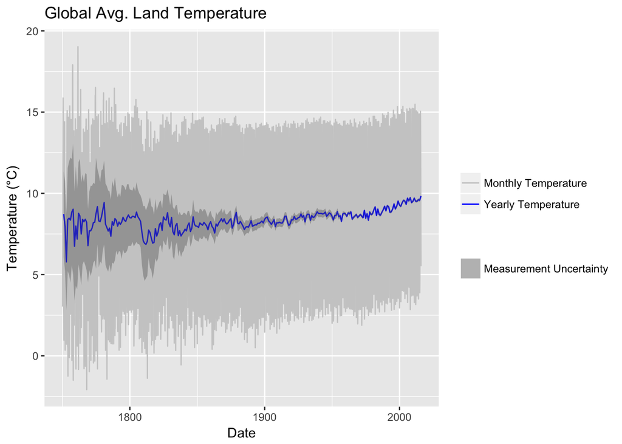

```r
landPlot <- ggplot(data=annualLandTemp) +
  geom_line(data=globalLandTemp, aes(x=date, y=temp, color="Monthly Temperature")) +
  geom_line(aes(x=as.Date(as.character(year),"%Y"), y=temp, color="Yearly Temperature")) +
  geom_ribbon(aes(x=as.Date(as.character(year),"%Y"), ymax = temp + merr, ymin = temp - merr,
                  fill="Measurement Uncertainty"),
              alpha = 0.4) +
  labs(x="Date", y="Temperature (°C)", title="Global Avg. Land Temperature")
landPlot +
  scale_color_manual("", values=c("grey80","blue")) +
  scale_fill_manual("", values="grey40")
```

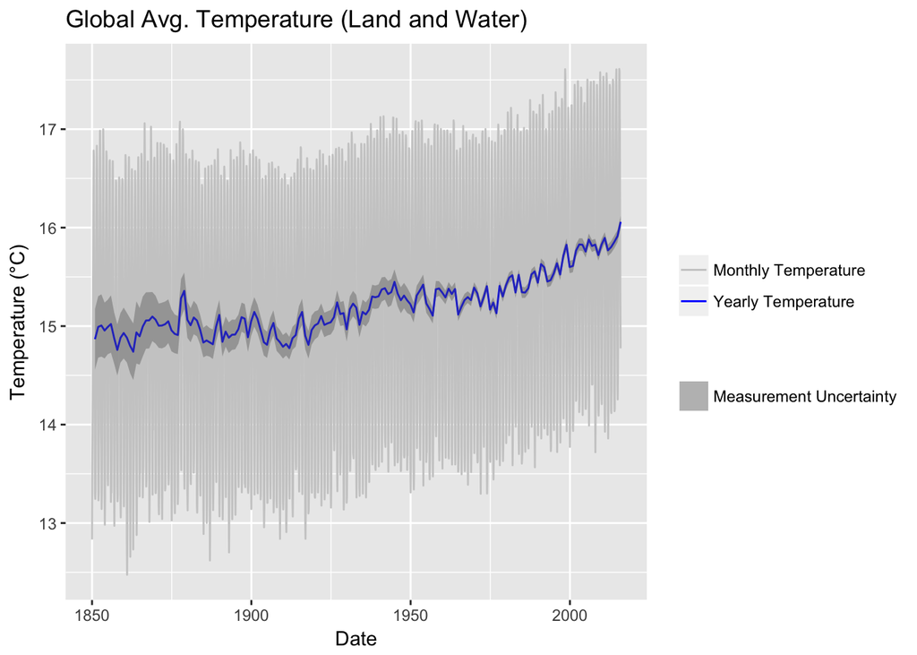

```r
combPlot <- ggplot(data=annualCombTemp) +
  geom_line(data=globalCombTemp, aes(x=date, y=temp, color="Monthly Temperature")) +
  geom_line(aes(x=as.Date(as.character(year),"%Y"), y=temp, color="Yearly Temperature")) +
  geom_ribbon(aes(x=as.Date(as.character(year),"%Y"), ymax = temp + merr, ymin = temp - merr,
                  fill="Measurement Uncertainty"),
              alpha = 0.4) +
  labs(x="Date", y="Temperature (°C)", title="Global Avg. Temperature (Land and Water)")
combPlot +
  scale_color_manual("", values=c("grey80","blue")) +
  scale_fill_manual("", values="grey40")
```

## Interpolation

The simplest train-test splitting we could do would be to randomly select some percentage of the years to be test data. Interpolating climate data is not nearly as useful as forecasting climate data, though.

### Train-Test Split: 60:40

```r
set.seed(12345)
train_ids <- sapply(X = 1:length(annualLandTemp$year),
                    FUN = function(i) sample(x=c("train","test"), size=1, prob=c(.6,.4)))

landRand <- with(annualLandTemp, data.frame(train_id=train_ids, temp=temp, year=year, merr=merr))
```

### No Homoskedasticity

Our analysis has been violating model assumptions left and right. It doesn’t make much of a difference in this case, but one of those assumptions is homoskedasticity: the variability in the response should not depend on the predictors. However, in our data we can see greater variability in early measurements, which we expect to be related to the imprecision of records and instruments in the 1700s and 1800s.

One way to address heteroskedasticity is to minimize a *weighted* sum of squared errors, so that higher-variability regions exert less undue leverage on the line of best fit (or equivalent).

### Basis Expansion

There is evidence that temperature change accelerated in the 20th century, so we guess at a basis expansion.

```r
X <- as.matrix(with(landRand, data.frame(intercept = rep(1, dim(landRand)[1]),
                                         x1 = year - 1900,
                                         x2 = (year - 1900)^2,
                                         x3 = (year - 1900)^3)))
y <- landRand$temp

X_train <- X[landRand$train_id=='train',]
y_train <- y[landRand$train_id=='train']

beta <- lm.wfit(X_train, y_train, w=1/sqrt(landRand$merr[landRand$train_id=='train']))$coef
land_temp_pred_exp <- X %*% beta
sqrt(tapply((landRand$temp - land_temp_pred_exp)^2, landRand$train_id, mean))
```

```
##      test     train
## 0.4191784 0.3826280
```

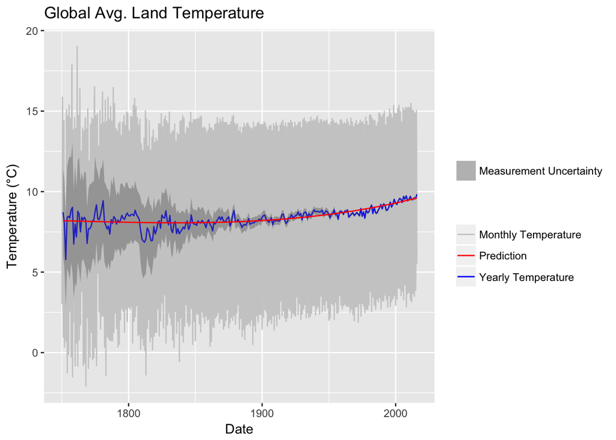

### GAM

An alternative to guessing at a basis expansion is to generate the expansion behind the scenes with a smoothing function.

```r
library(gam)
model_land_random_gam <- gam(temp ~ s(year), data=landRand[landRand$train_id=='train',],
                             weights=1/sqrt(merr))
land_temp_pred_gam <- predict(model_land_random_gam, landRand)
sqrt(tapply((landRand$temp - land_temp_pred_gam)^2, landRand$train_id, mean))
```

```
##      test     train
## 0.4177118 0.3707573
```

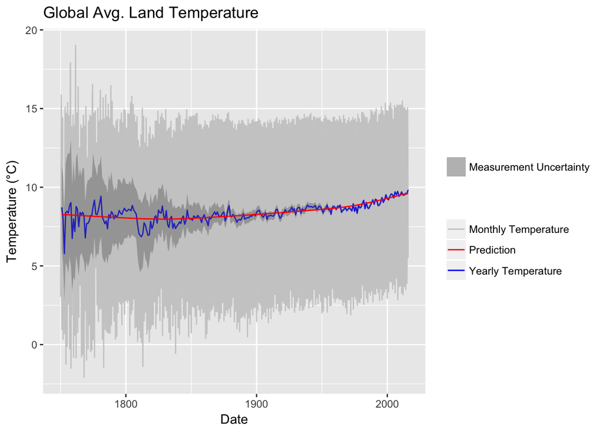

## Forecasting

Predicting future climate data seems more useful than interpolating data points, and for this we will need a new train-test split. We will try to predict temperatures over the past 35 years (1981—2015) given temperature data from 1850—1980.

```r
train_ids <- sapply(annualCombTemp$year, function(year) if(year > 1980){"test"} else {"train"})
combForecast <- with(annualCombTemp, data.frame(train_id=train_ids, temp=temp, year=year, merr=merr))
```

### GAM

As expected, extrapolating a spline performs poorly. The prediction is mostly just tangent to the existing curve, and the angle thereof is highly dependent on the complexity we choose for the curve

```
##      test     train
## 0.2642558 0.1017189
```

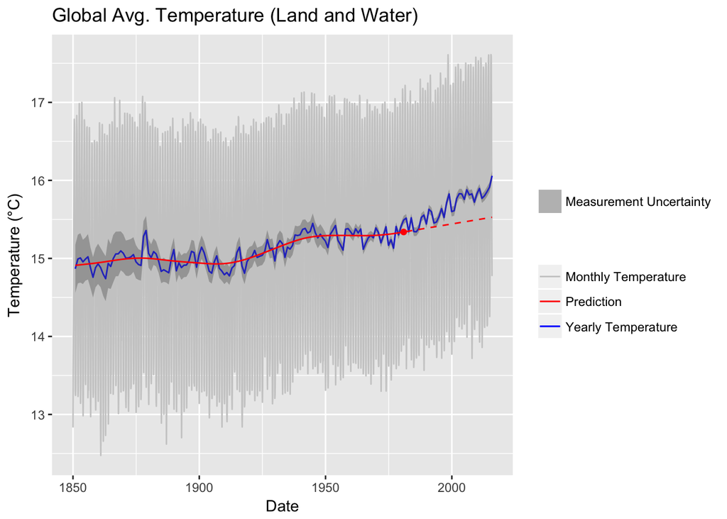

### Autocorrelation and ARIMA

A much larger violation of model assumptions is autocorrelation: time-series data are generally highly correlated with data in a recent, previous window of time. (For example, it may be more accurate to predict the temperature in 1981 by the temperature in 1980, rather than just some function of the year 1981. This would be “an autocorrelation” at a lag of 1 year. If there’s an 11-year solar cycle or something, then there would also be an autocorrelation at a lag of 11 years.)

An out-of-the-box tool for forecasting time-series data is ARIMA: the Auto-Regressive Integrated Moving Average. At a high level, ARIMA looks for an overall trend and then high-frequency cycles and low-frequency seasonal variations in the residuals not predicted by the trend.

```r
library(forecast)
model_comb_forecast_arima <- auto.arima(y=combForecast$temp[combForecast$train_id=='train'])
comb_temp_pred_arima <- combForecast$temp[combForecast$train_id=='train']
fcast <- predict(model_comb_forecast_arima, n.ahead = 35)
comb_temp_pred_arima <- append(comb_temp_pred_arima, fcast$pred)
sqrt(tapply((combForecast$temp - comb_temp_pred_arima)^2, combForecast$train_id, mean))
```

```
##      test     train
## 0.3474893 0.0000000
```

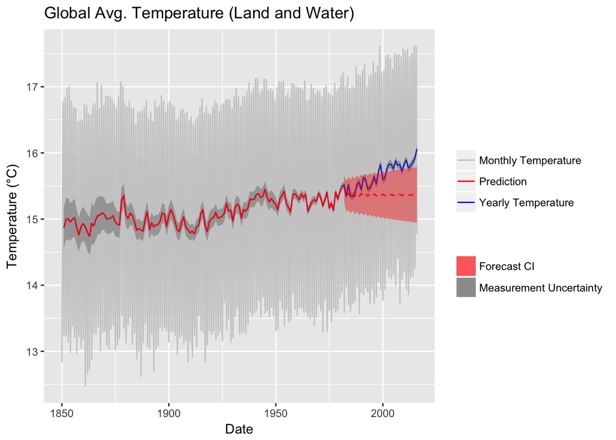

Choosing appropriate parameters for ARIMA can perform significantly better than auto-selecting parameters but requires more advanced analysis.

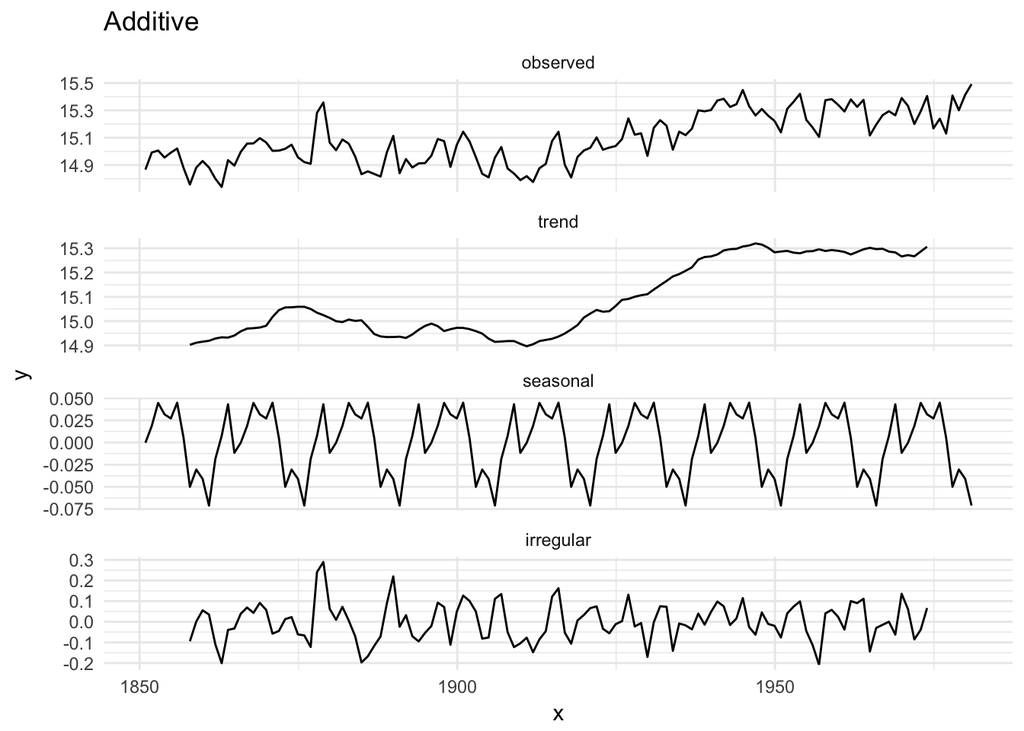

```r
library(ggseas)
tseries <- data.frame(y=combForecast$temp[combForecast$train_id=='train'],
                      date=as.Date(as.character(combForecast$year[combForecast$train_id=='train']),
                                   "%Y"))

tmp_a <- ggsdc(tseries, aes(x = date, y = y), method = "decompose",
      frequency = 15, s.window = 11, type = "additive")
tmp_a + geom_line()+
  ggtitle("Additive")+ theme_minimal()
```

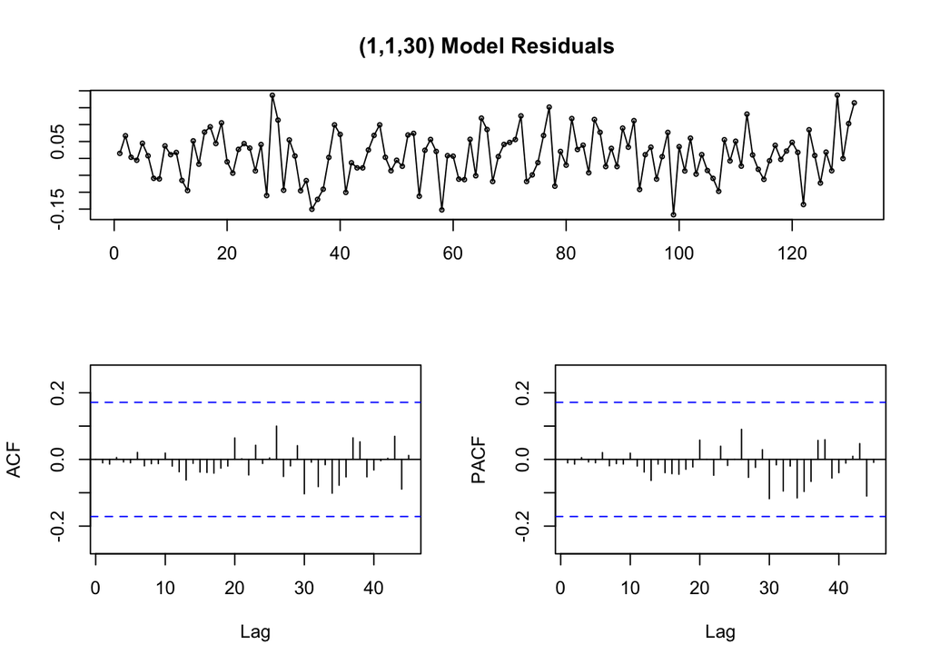

```r
# note: extract series 4 as > resid_m <- tmp$data$y[(3*131 + 1):(4*131)]
tseries$seasonal_a <- tmp_a$data$y[(2*131 + 1):(3*131)]

#fit<-auto.arima((tseries$y - tseries$seasonal_a), seasonal=FALSE)
#fit
#tsdisplay(residuals(fit), lag.max=45, main='(1,1,1) Model Residuals')

fit2<-arima((tseries$y - tseries$seasonal_a), order=c(1,1,30))
tsdisplay(residuals(fit2), lag.max=45, main='(1,1,30) Model Residuals')
```

```r
comb_temp_pred_arima2 <- combForecast$temp[combForecast$train_id=='train']
fcast <- predict(fit2, n.ahead = 35)
comb_temp_pred_arima2 <- append(comb_temp_pred_arima2, fcast$pred +
                                  tseries$seasonal_a[(131%%15):((131%%15)+35-1)])
sqrt(tapply((combForecast$temp - comb_temp_pred_arima2)^2, combForecast$train_id, mean))
```

```
##    test   train
## 0.25748 0.00000
```

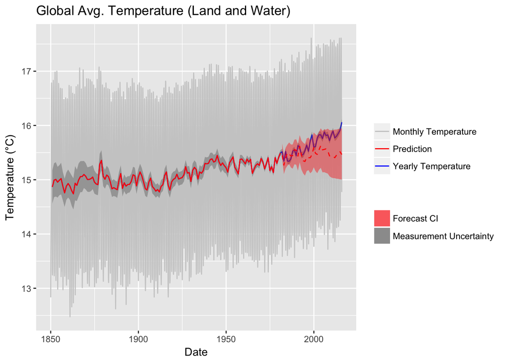